# source_data

Autogenerated data summary from dataReporter

2026-01-05 18:06:43.957121

# Data report overview

The dataset examined has the following dimensions:

[output not shown]

### Checks performed

The following variable checks were performed, depending on the data type of each variable:

|  | character | factor | labelled | haven labelled | numeric | integer | logical | Date |
| --- | --- | --- | --- | --- | --- | --- | --- | --- |
| Identify miscoded missing values | × | × | × | × | × | × |  | × |
| Identify prefixed and suffixed whitespace | × | × | × | × |  |  |  |  |
| Identify levels with < 6 obs. | × | × | × | × |  |  |  |  |
| Identify case issues | × | × | × | × |  |  |  |  |
| Identify misclassified numeric or integer variables | × | × | × | × |  |  |  |  |
| Identify outliers |  |  |  |  | × | × |  | × |

Please note that all numerical values in the following have been rounded to 2 decimals.

# Summary table

|  | Variable class | # unique values | Missing observations | Any problems? |
| --- | --- | --- | --- | --- |
| persoonsgebonden_nummer | numeric | 711 | 0.00 % |  |
| inschrijvingsjaar | numeric | 20 | 0.00 % | × |
| instellingscode | character | 1 | 0.00 % | × |
| actuele_instelling | character | 1 | 0.00 % | × |
| opleidingscode | numeric | 23 | 0.00 % |  |
| opleidingsvorm | numeric | 2 | 0.00 % |  |
| opleidingsfase | character | 3 | 0.00 % | × |
| maand_vanaf | numeric | 12 | 0.00 % | × |

# Variable list

## persoonsgebonden_nummer

| Feature | Result |
| --- | --- |
| Variable type | numeric |
| Number of missing obs. | 0 (0 %) |
| Number of unique values | 711 |
| Median | 1597.5 |
| 1st and 3rd quartiles | 843.25; 2390 |
| Min. and max. | 2; 3235 |

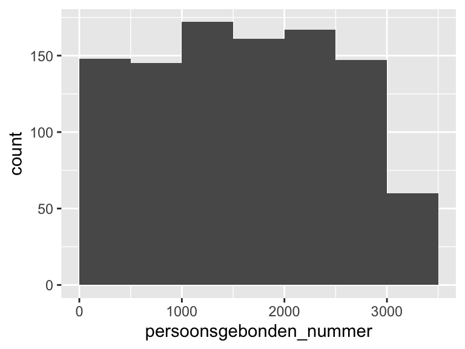

## inschrijvingsjaar

| Feature | Result |
| --- | --- |
| Variable type | numeric |
| Number of missing obs. | 0 (0 %) |
| Number of unique values | 20 |
| Median | 2011 |
| 1st and 3rd quartiles | 2009; 2013 |
| Min. and max. | 2004; 2023 |

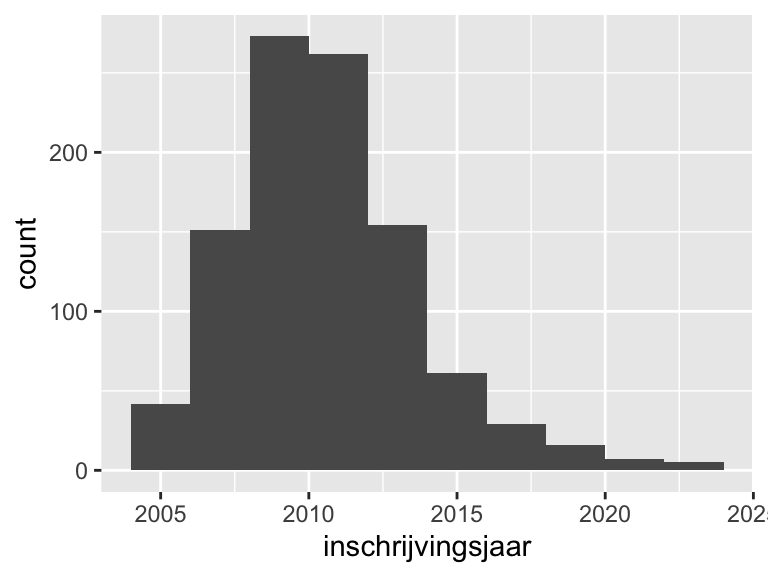

- Note that the following possible outlier values were detected: "2020", "2021", "2022", "2023".

## instellingscode

- The variable only takes one (non-missing) value: "21PL". The variable contains 0 % missing observations.

## actuele_instelling

- The variable only takes one (non-missing) value: "21PL". The variable contains 0 % missing observations.

## opleidingscode

| Feature | Result |
| --- | --- |
| Variable type | numeric |
| Number of missing obs. | 0 (0 %) |
| Number of unique values | 23 |
| Median | 59324 |
| 1st and 3rd quartiles | 56553; 66588 |
| Min. and max. | 50509; 66950 |

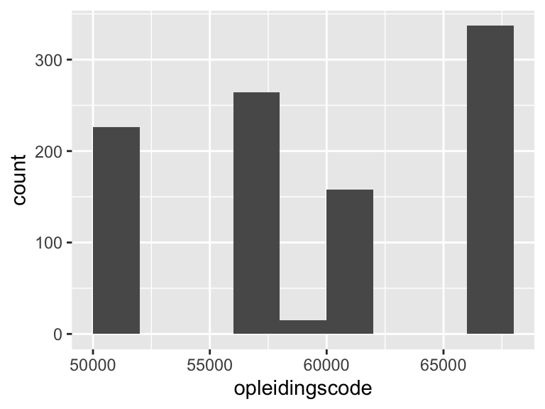

## opleidingsvorm

- Note that this variable is treated as a factor variable below, as it only takes a few unique values.

| Feature | Result |
| --- | --- |
| Variable type | numeric |
| Number of missing obs. | 0 (0 %) |
| Number of unique values | 2 |
| Mode | “1” |
| Reference category | 1 |

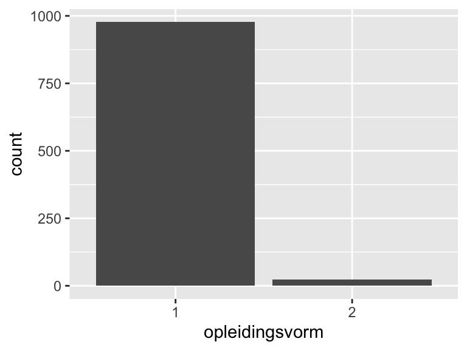

## opleidingsfase

| Feature | Result |
| --- | --- |
| Variable type | character |
| Number of missing obs. | 0 (0 %) |
| Number of unique values | 3 |
| Mode | “B” |

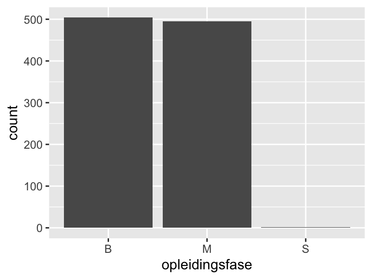

- Note that the following levels have at most five observations: "S".

## maand_vanaf

| Feature | Result |
| --- | --- |
| Variable type | numeric |
| Number of missing obs. | 0 (0 %) |
| Number of unique values | 12 |
| Median | 9 |
| 1st and 3rd quartiles | 9; 9 |
| Min. and max. | 1; 12 |

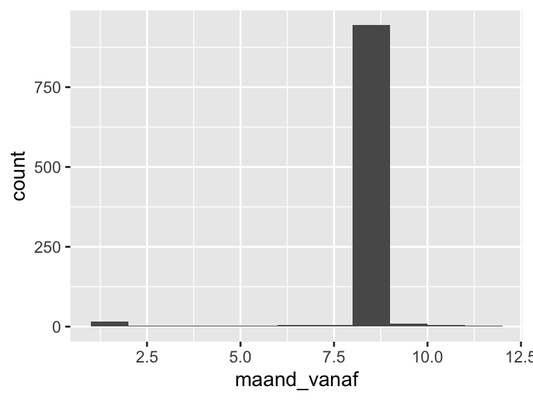

- Note that the following possible outlier values were detected: "1", "2", "3", "4", "5", …, "7", "8", "10", "11", "12" (1 values omitted).

Report generation information:

- Created by: Corneel den Hartogh (username: `corneeldenhartogh`).
- Report creation time: Mon Jan 05 2026 18:06:44
- Report was run from directory: `/Users/corneeldenhartogh/repositories/1cho_ins_preparation_r`
- dataReporter v1.0.2 [Pkg: 2021-11-11 from CRAN (R 4.4.0)]
- R version 4.4.3 (2025-02-28).
- Platform: aarch64-apple-darwin20(Europe/Amsterdam).
- Function call: `dataReporter::makeDataReport(data = source_data, output = "html", file = output_file, replace = TRUE)`